# Task 2,4 & 5

### Task No.5

**`Implement an anomaly detection system using Isolation Forest and Local Outlier Factor (LOF) on a dataset`**. .

| Step | Description |
| --- | --- |
| 1. Exploring Dataset | Start by **loading** and **analyzing** the dataset to understand its features and structure. This step is crucial for preparing the data for clustering. |
| 2. Data Separation | Perform **data separation** to identify distinct groups or clusters within the dataset, which will aid in the clustering process. |
| 3. Standardization | Apply **standardization** techniques to normalize the data. This step helps in improving the performance and accuracy of the clustering algorithm. |
| 4. Defining Functions for Anomaly Detection and Plotting | Define functions for **anomaly detection** and **plotting**. This includes setting up evaluation metrics and visualizations for assessing anomalies. |
| 5. Evaluating Methods and Plotting Results | Evaluate **anomaly detection methods** such as Isolation Forest and Local Outlier Factor. Plot **ROC curves**, **accuracy**, and **classification reports** to compare the performance of these methods. |
| 6. Comparing Results | Compare the results from different **anomaly detection methods** and visualizations to determine the best-performing approach. |

## Isolation Forest & Local Outlier Factor (LOF)

**Outlier detection** is crucial for identifying anomalies or unusual patterns in data, which can be vital for tasks like fraud detection, network security, and data cleaning. Two popular techniques for outlier detection are **Isolation Forest** and **Local Outlier Factor (LOF)**.

### Isolation Forest

**Isolation Forest** is an algorithm designed to detect anomalies by isolating observations in a dataset. It operates under the principle that anomalies are easier to isolate than normal observations due to their rarity and distinctiveness.

- **How It Works:**
  - **Isolation:** The algorithm builds a forest of random trees, where each tree isolates a data point by randomly selecting features and splitting the data.
  - **Path Length:** The isolation is measured by the path length in the trees. Anomalies, being rare, tend to have shorter path lengths compared to normal observations.
- **Advantages:**
  - **Efficiency:** Isolation Forest is computationally efficient and scales well with large datasets.
  - **Simplicity:** It does not require assumptions about the data distribution and works well with high-dimensional data.
- **Applications:**
  - **Fraud Detection:** Identifying unusual financial transactions.
  - **Anomaly Detection:** Detecting rare events or outliers in various domains.

### Local Outlier Factor (LOF)

**Local Outlier Factor (LOF)** is another powerful method for detecting anomalies, focusing on the local density of data points. LOF identifies outliers by comparing the density of a data point with the densities of its neighbors.

- **How It Works:**
  - **Local Density:** LOF calculates the local density of each data point relative to its neighbors.
  - **Outlier Score:** Data points with significantly lower densities compared to their neighbors are assigned higher LOF scores, indicating they are potential outliers.
- **Advantages:**
  - **Local Perspective:** LOF captures anomalies that might be local to a particular region of the data, which is useful for detecting contextual anomalies.
  - **Flexibility:** It does not assume a global data distribution and can adapt to varying density levels.
- **Applications:**
  - **Fraud Detection:** Uncovering unusual patterns in transaction data.
  - **Data Cleaning:** Identifying and removing anomalies from datasets.

Both Isolation Forest and Local Outlier Factor offer robust solutions for outlier detection, each with its unique strengths. Isolation Forest is efficient and well-suited for large datasets, while LOF provides a nuanced view of anomalies by focusing on local data density.

### Section 1 : Exploring Dataset

### Importing Libraries

```python
import numpy as np
import pandas as pd
from sklearn.ensemble import IsolationForest
from sklearn.neighbors import LocalOutlierFactor
from sklearn.preprocessing import StandardScaler
from sklearn.model_selection import train_test_split, GridSearchCV
from sklearn.metrics import roc_curve, auc, confusion_matrix, accuracy_score, classification_report, make_scorer
import matplotlib.pyplot as plt
from tabulate import tabulate
from pylab import rcParams
import matplotlib.pyplot as plt
import seaborn as sns
from matplotlib.colors import ListedColormap
```

```python
df = pd.read_csv(r"C:\Users\acer\Documents\creditcard.csv")
df.head()
```

|  | Time | V1 | V2 | V3 | V4 | V5 | V6 | V7 | V8 | V9 | ... | V21 | V22 | V23 | V24 | V25 | V26 | V27 | V28 | Amount | Class |
| --- | --- | --- | --- | --- | --- | --- | --- | --- | --- | --- | --- | --- | --- | --- | --- | --- | --- | --- | --- | --- | --- |
| 0 | 0.0 | -1.359807 | -0.072781 | 2.536347 | 1.378155 | -0.338321 | 0.462388 | 0.239599 | 0.098698 | 0.363787 | ... | -0.018307 | 0.277838 | -0.110474 | 0.066928 | 0.128539 | -0.189115 | 0.133558 | -0.021053 | 149.62 | 0 |
| 1 | 0.0 | 1.191857 | 0.266151 | 0.166480 | 0.448154 | 0.060018 | -0.082361 | -0.078803 | 0.085102 | -0.255425 | ... | -0.225775 | -0.638672 | 0.101288 | -0.339846 | 0.167170 | 0.125895 | -0.008983 | 0.014724 | 2.69 | 0 |
| 2 | 1.0 | -1.358354 | -1.340163 | 1.773209 | 0.379780 | -0.503198 | 1.800499 | 0.791461 | 0.247676 | -1.514654 | ... | 0.247998 | 0.771679 | 0.909412 | -0.689281 | -0.327642 | -0.139097 | -0.055353 | -0.059752 | 378.66 | 0 |
| 3 | 1.0 | -0.966272 | -0.185226 | 1.792993 | -0.863291 | -0.010309 | 1.247203 | 0.237609 | 0.377436 | -1.387024 | ... | -0.108300 | 0.005274 | -0.190321 | -1.175575 | 0.647376 | -0.221929 | 0.062723 | 0.061458 | 123.50 | 0 |
| 4 | 2.0 | -1.158233 | 0.877737 | 1.548718 | 0.403034 | -0.407193 | 0.095921 | 0.592941 | -0.270533 | 0.817739 | ... | -0.009431 | 0.798278 | -0.137458 | 0.141267 | -0.206010 | 0.502292 | 0.219422 | 0.215153 | 69.99 | 0 |

5 rows × 31 columns

### Summary of Data

```python
df.info()
```

```
<class 'pandas.core.frame.DataFrame'>
RangeIndex: 284807 entries, 0 to 284806
Data columns (total 31 columns):
 #   Column  Non-Null Count   Dtype
---  ------  --------------   -----
 0   Time    284807 non-null  float64
 1   V1      284807 non-null  float64
 2   V2      284807 non-null  float64
 3   V3      284807 non-null  float64
 4   V4      284807 non-null  float64
 5   V5      284807 non-null  float64
 6   V6      284807 non-null  float64
 7   V7      284807 non-null  float64
 8   V8      284807 non-null  float64
 9   V9      284807 non-null  float64
```

[output cut: 23 more lines]

```python
# Get the fraud and normal datasets
fraud = df[df['Class'] == 1]
normal = df[df['Class'] == 0]

# Print the number of fraud and normal transactions
print("Number of Fraud Transactions:", len(fraud))
print("Number of Normal Transactions:", len(normal))
```

```
Number of Fraud Transactions: 492
Number of Normal Transactions: 284315
```

### Section 2 : Data Separation & Standardlization

```python
# Create independent and dependent features
columns = df1.columns.tolist()
columns = [c for c in columns if c not in ["Class"]]
target = "Class"
X = df1[columns]
Y = df1[target]
```

### Section 3 : Standardlization

```python
# Standardize the features
scaler = StandardScaler()
X_scaled = scaler.fit_transform(X)
print("Data preprocessing complete. Features scaled.")
# Print the shapes of the independent and dependent features
print("X Shape:", X.shape)
print("Y Shape:", Y.shape)
```

```
Data preprocessing complete. Features scaled.
X Shape: (28480, 30)
Y Shape: (28480,)
```

```python
X_scaled_df = pd.DataFrame(X_scaled)
X_scaled_df.head()
```

|  | 0 | 1 | 2 | 3 | 4 | 5 | 6 | 7 | 8 | 9 | ... | 20 | 21 | 22 | 23 | 24 | 25 | 26 | 27 | 28 | 29 |
| --- | --- | --- | --- | --- | --- | --- | --- | --- | --- | --- | --- | --- | --- | --- | --- | --- | --- | --- | --- | --- | --- |
| 0 | 0.326371 | -1.244115 | 1.281249 | -3.382039 | 0.994215 | -1.224757 | -0.549590 | -2.939204 | 1.558040 | -0.719907 | ... | -0.170704 | 1.045044 | 0.494155 | 0.350686 | -0.461071 | -0.608315 | 1.026122 | 0.881524 | -0.332228 | -0.035490 |
| 1 | -1.142216 | -1.207024 | 0.315191 | -5.324804 | 5.641971 | 1.912744 | -2.530423 | -1.553381 | 0.460078 | -2.833270 | ... | -0.832363 | 0.193158 | 0.982830 | 4.038034 | -0.834599 | -0.761988 | 1.222485 | 1.224985 | 1.576826 | -0.368622 |
| 2 | -0.930459 | -4.666001 | 4.315095 | -8.126919 | 2.990160 | -5.198239 | -2.534191 | -6.477035 | 5.130073 | -2.202594 | ... | 1.071889 | 1.209111 | -1.126599 | -0.232626 | -0.060910 | 0.914237 | -0.544189 | 2.838564 | 0.664111 | 0.047646 |
| 3 | -0.761869 | -2.228936 | 1.985430 | -2.024687 | 2.398463 | -1.403883 | -0.912524 | -2.659696 | -0.869544 | -1.805233 | ... | -0.185261 | 2.711381 | -1.363199 | -0.505908 | 0.265163 | 0.008796 | -1.020181 | -3.762304 | -2.845905 | -0.180904 |
| 4 | -0.014216 | -13.469941 | 10.039710 | -19.850883 | 6.275486 | -12.960385 | -0.917633 | -25.081985 | -9.070561 | -8.636382 | ... | 3.690126 | -11.436027 | 4.738601 | 1.357594 | 0.424205 | -1.397569 | -2.000436 | -17.774406 | -3.792553 | -0.368622 |

5 rows × 30 columns

### Section 4 : Definitions

### Methods Definition

```python
# Define the outlier detection methods
classifiers = {
    "Isolation Forest": IsolationForest(n_estimators=100, max_samples=len(X_scaled), contamination=0.1, random_state=5, verbose=0),
    "Local Outlier Factor": LocalOutlierFactor(n_neighbors=20, algorithm='auto', leaf_size=30, metric='minkowski', p=2, contamination=0.1)
}
```

### Plotting Functions Definition

```python
# Helper function to plot ROC curve
def plot_roc_curve(fpr, tpr, clf_name, roc_auc):
    plt.plot(fpr, tpr, lw=2, label=f"{clf_name} (area = {roc_auc:.2f})")
    plt.xlabel('False Positive Rate')
    plt.ylabel('True Positive Rate')
    plt.title('ROC Curve')
    plt.legend(loc='lower right')
    plt.grid(True)


# Set a seaborn style for better aesthetics
sns.set(style="whitegrid")

def plot_anomaly_detection(X, y_pred, clf_name):
    # Create a color palette
    light_palette = ListedColormap(sns.color_palette("coolwarm", 3).as_hex())

    # Plot scatter plot for anomaly detection
    plt.figure(figsize=(12, 6))
    scatter = plt.scatter(X[:, 0], X[:, 1], c=y_pred, cmap=light_palette, edgecolor='k', s=50)

    # Add colorbar
    cbar = plt.colorbar(scatter)
    cbar.set_label('Anomaly Score', rotation=270, labelpad=20)

    # Add labels, title, and grid
    plt.xlabel('Feature 1', fontsize=14)
    plt.ylabel('Feature 2', fontsize=14)
    plt.title(f"Anomaly Detection using {clf_name}", fontsize=16)
    plt.legend(handles=scatter.legend_elements()[0], labels=['Normal', 'Anomaly'], loc='upper right', fontsize=12)
    plt.grid(True, linestyle='--', alpha=0.7)

    # Customize tick parameters
    plt.xticks(fontsize=12)
    plt.yticks(fontsize=12)

    # Add axis lines for better readability
    plt.axhline(y=0, color='k', linestyle='--', linewidth=0.7)
    plt.axvline(x=0, color='k', linestyle='--', linewidth=0.7)

    # Show plot
    plt.tight_layout()
    plt.show()
```

### Section 5 : Evaluation

### Using ROC_AUC

```
Classifier: Isolation Forest
Classifier: Local Outlier Factor
```

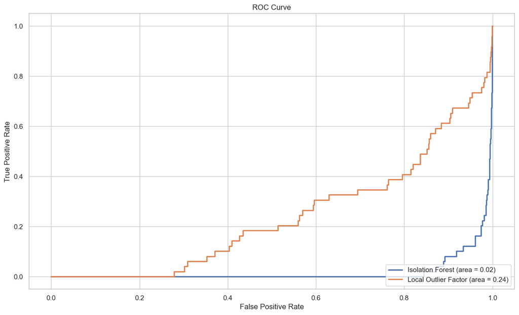

```python
# Iterate over the classifiers and perform anomaly detection
for clf_name, clf in classifiers.items():
    print("Classifier:", clf_name)

    # Fit the data and tag outliers
    if clf_name == "Local Outlier Factor":
        y_pred = clf.fit_predict(X_scaled)
        scores_prediction = clf.negative_outlier_factor_
    else:
        clf.fit(X_scaled)
        scores_prediction = clf.decision_function(X_scaled)
        y_pred = clf.predict(X_scaled)

    # Evaluate the performance of the classifier
    y_pred_binary = [1 if y == -1 else 0 for y in y_pred]
    results[clf_name] = {
        "Total Anomalies Detected": sum(y_pred_binary),
        "Confusion Matrix": confusion_matrix(Y, y_pred_binary),
        "Accuracy": accuracy_score(Y, y_pred_binary),
        "Classification Report": classification_report(Y, y_pred_binary, output_dict=True),
        "ROC AUC": auc(roc_curve(Y, scores_prediction)[0], roc_curve(Y, scores_prediction)[1]),
    }

    # Plot the ROC curve
    fpr, tpr, _ = roc_curve(Y, scores_prediction)
    roc_auc = auc(fpr, tpr)
    plot_roc_curve(fpr, tpr, clf_name, roc_auc)
```

### Indiviuals

[output not shown]

[figure not shown]

[output not shown]

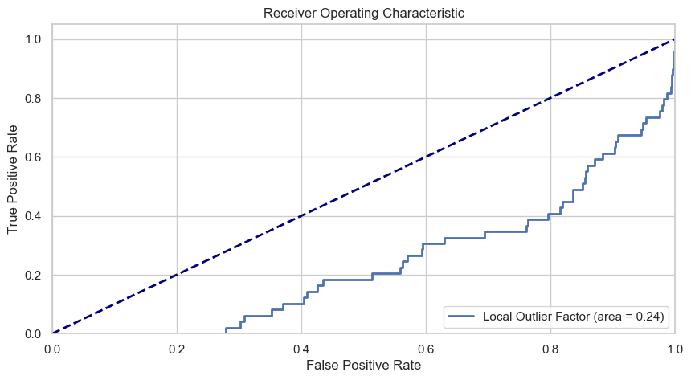

```python
#Plot the ROC curve
fpr, tpr, _ = roc_curve(Y, scores_prediction)
roc_auc = auc(fpr, tpr)
plt.figure(figsize=(10, 5))
plot_roc_curve(fpr, tpr, clf_name, roc_auc)
plt.plot([0, 1], [0, 1], color='navy', lw=2, linestyle='--')
plt.xlim([0.0, 1.0])
plt.ylim([0.0, 1.05])
plt.xlabel('False Positive Rate')
plt.ylabel('True Positive Rate')
plt.title('Receiver Operating Characteristic')
plt.legend(loc="lower right")
plt.grid(True)
plt.show()
```

### Anamoly Detection

```
Classifier: Isolation Forest
```

[figure not shown]

```
Classifier: Local Outlier Factor
```

[figure not shown]

```python
for clf_name, clf in classifiers.items():
    print("Classifier:", clf_name)

    # Fit the data and tag outliers
    if clf_name == "Local Outlier Factor":
        y_pred = clf.fit_predict(X_scaled)
        scores_prediction = clf.negative_outlier_factor_
    else:
        clf.fit(X_scaled)
        scores_prediction = clf.decision_function(X_scaled)
        y_pred = clf.predict(X_scaled)
    # Plot the anomaly detection
    plot_anomaly_detection(X_scaled, y_pred, clf_name)
```

### Report

```python
# Print the results in a tabulated form
print("Results:")
for clf_name, result in results.items():
    print(f"{clf_name}:")
    print(f"  Total Anomalies Detected: {result['Total Anomalies Detected']}")
    print(f"  Confusion Matrix:\n{result['Confusion Matrix']}")
    print(f"  Accuracy: {result['Accuracy']:.2f}")

    # Convert classification report to DataFrame for better formatting
    report_df = pd.DataFrame(result['Classification Report']).transpose()
    report_df = report_df.round(2)

    # Tabulate the classification report
    classification_table = tabulate(report_df, headers='keys', tablefmt='grid', showindex=True, numalign='center')
    print(f"  Classification Report:\n{classification_table}")
    print(f"  ROC AUC: {result['ROC AUC']:.2f}")
    print()
```

```
Results:
Isolation Forest:
  Total Anomalies Detected: 2848
  Confusion Matrix:
[[25628  2803]
 [    4    45]]
  Accuracy: 0.90
  Classification Report:
+--------------+-------------+----------+------------+-----------+
|              |  precision  |  recall  |  f1-score  |  support  |
+==============+=============+==========+============+===========+
| 0            |      1      |   0.9    |    0.95    |   28431   |
+--------------+-------------+----------+------------+-----------+
| 1            |    0.02     |   0.92   |    0.03    |    49     |
+--------------+-------------+----------+------------+-----------+
| accuracy     |     0.9     |   0.9    |    0.9     |    0.9    |
+--------------+-------------+----------+------------+-----------+
| macro avg    |    0.51     |   0.91   |    0.49    |   28480   |
+--------------+-------------+----------+------------+-----------+
| weighted avg |      1      |   0.9    |    0.95    |   28480   |
+--------------+-------------+----------+------------+-----------+
  ROC AUC: 0.02

Local Outlier Factor:
  Total Anomalies Detected: 2848
  Confusion Matrix:
[[25602  2829]
 [   30    19]]
  Accuracy: 0.90
  Classification Report:
+--------------+-------------+----------+------------+-----------+
|              |  precision  |  recall  |  f1-score  |  support  |
+==============+=============+==========+============+===========+
| 0            |      1      |   0.9    |    0.95    |   28431   |
+--------------+-------------+----------+------------+-----------+
| 1            |    0.01     |   0.39   |    0.01    |    49     |
+--------------+-------------+----------+------------+-----------+
| accuracy     |     0.9     |   0.9    |    0.9     |    0.9    |
+--------------+-------------+----------+------------+-----------+
| macro avg    |     0.5     |   0.64   |    0.48    |   28480   |
+--------------+-------------+----------+------------+-----------+
| weighted avg |      1      |   0.9    |    0.95    |   28480   |
+--------------+-------------+----------+------------+-----------+
  ROC AUC: 0.24
```

### Section 6 : Comaprison

**Remarks on Comparison:**

In this section, we compare the performance of various anomaly detection methods, including Isolation Forest and Local Outlier Factor. The comparison is based on several evaluation metrics, such as ROC curves, accuracy scores, and classification reports. Each method offers distinct advantages and limitations:

- **Isolation Forest:** This method is highly effective in detecting anomalies in high-dimensional datasets due to its ability to isolate anomalies efficiently. It performs well with large datasets and is robust against noisy data. However, it may not always provide optimal results for datasets with overlapping clusters or complex structures.
- **Local Outlier Factor (LOF):** LOF excels in identifying local anomalies by comparing the density of data points. It is particularly useful for datasets with varying densities and can capture subtle anomalies that other methods might miss. Nonetheless, LOF may struggle with very large datasets and is sensitive to the choice of the parameter *k*, which influences its performance.